# Exercises 11 - Correlation and Linear Regression

Sadip Giri

```r
require(dplyr)
require(ggplot2)
require(mosaic)
```

# Exercise 1

The `road` dataset in the the `MASS`package contains a number of variables that could be related to the number of driving related fatalities in each state. These variables are the population density in people per square mile (`popden`), the length of rural roads, in 1000s of miles (`rural`), the average daily maximum temperature in January (`temp`), and the total `fuel` consumption in 10,000,000 US gallons per year for the state.

Which of these variables seem likely to be correlated to the total number of driving deaths in the state? `rural` variable seems likely to be correlated to the total number of driving deaths in the state (`deaths`).

Choose one of these factors and determine the strength of the correlation between this variable and the number of driving deaths. Do this by both creating a graph to show the relationship, and by finding the correlation coefficient.

```r
#Load in any required packages
library(MASS)

# view "road" data set
head(road)
```

```
##         deaths drivers popden rural temp  fuel
## Alabama    968     158   64.0  66.0   62 119.0
## Alaska      43      11    0.4   5.9   30   6.2
## Arizona    588      91   12.0  33.0   64  65.0
## Arkanas    640      92   34.0  73.0   51  74.0
## Calif     4743     952  100.0 118.0   65 105.0
## Colo       566     109   17.0  73.0   42  78.0
```

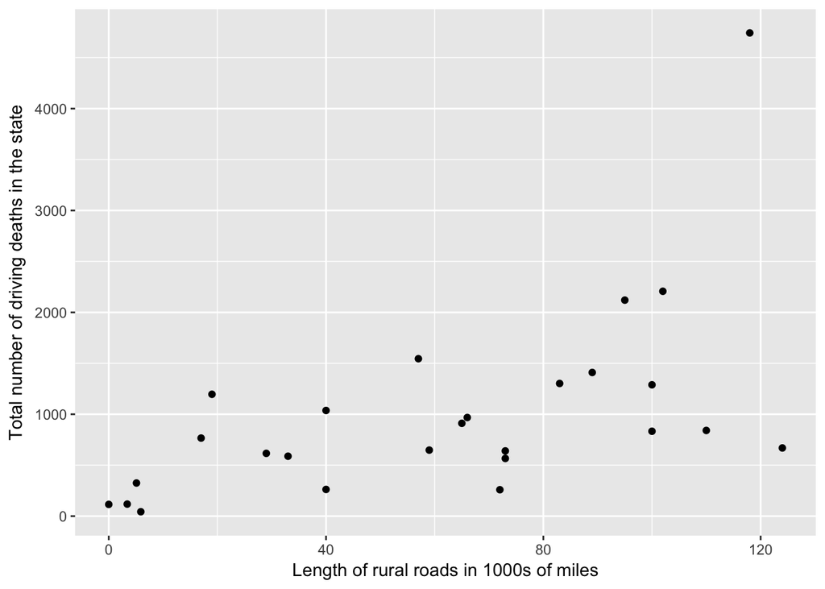

```r
#Create and graphics and determine the strength of the correlation.

# Visualization

# The length of rural roads is likely to affect the number of deaths in the state. So, I am considering rural as the independent variable (in X-axis) and number of deaths as dependent variable (in Y-axis).
ggplot(data = road, mapping = aes(x = rural, y = deaths)) +
        geom_point() +
        labs(x = "Length of rural roads in 1000s of miles", y = "Total number of driving deaths in the state")
```

```r
# Strength of Correlation

cor(road$rural, road$deaths)
```

```
## [1] 0.5628714
```

What does this tell you about driving-related deaths? i.e., how might you write about this result in a project writeup or a academic journal article?

There is a fairly strong correlation between the length of rural roads and total number of driving deaths in the state (R = 0.5628714).

# Exercise 2

Using the dataset `Galton` in the package `mosaicData`, determine the strength of the association between the average height of the biological parents of a child and the child when they are fully grown. You should also create a scatterplot of the data. Interpret and explain the results.

```r
#Load in required packages.
library(mosaicData)

#View "Galton" dataset
head(Galton)
```

```
##   family father mother sex height nkids
## 1      1   78.5   67.0   M   73.2     4
## 2      1   78.5   67.0   F   69.2     4
## 3      1   78.5   67.0   F   69.0     4
## 4      1   78.5   67.0   F   69.0     4
## 5      2   75.5   66.5   M   73.5     4
## 6      2   75.5   66.5   M   72.5     4
```

```r
?Galton
```

Note: you can look at information about the dataset by typing `?Galton` into the console and pressing enter.

```r
#Modify the dataset as necesary, create plots, and determine the strength of the association.

# Modify dataset

# Since, we are dealing with average height of biological parents so need to calculate the average between father and mother for our correlation study

newGalton <- Galton %>%
        mutate(average_height_parents = (father + mother)/2)

head(newGalton)
```

```
##   family father mother sex height nkids average_height_parents
## 1      1   78.5   67.0   M   73.2     4                  72.75
## 2      1   78.5   67.0   F   69.2     4                  72.75
## 3      1   78.5   67.0   F   69.0     4                  72.75
## 4      1   78.5   67.0   F   69.0     4                  72.75
## 5      2   75.5   66.5   M   73.5     4                  71.00
## 6      2   75.5   66.5   M   72.5     4                  71.00
```

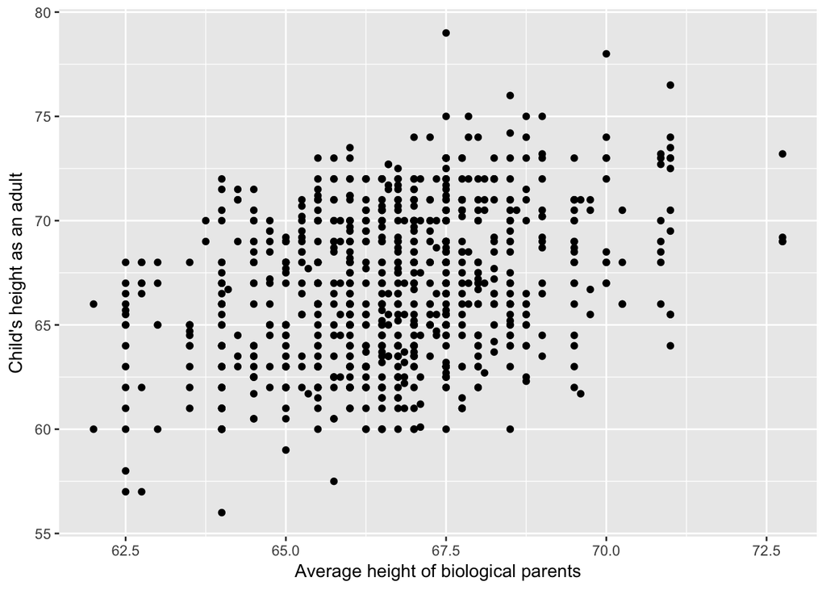

```r
# Visualization
# here, dependent variable will be child's height as an adult(in inches) and independent variable will be average of their biological parents.

ggplot(data = newGalton, mapping = aes(x = average_height_parents, y = height)) +
        geom_point() +
        labs(x = "Average height of biological parents", y = "Child's height as an adult")
```

```r
# Strength of correlation

cor(newGalton$average_height_parents, newGalton$height)
```

```
## [1] 0.3270739
```

What does this tell you about the relationship between a child’s height and their biological parents height? Write about this result as you would in a project writeup or a academic journal article.

There is a positive strength of the association between the average height of the biological parents of a child and height of the child when they are fully grown (R = 0.3270739).

# Exercise 3

You are visiting old faithful and show up to old faithful 5 minutes after the last eruption. The visitors that are still in the area tell you that the last eruption was 4.2 minutes long. You want to predict the length of time to the next eruption using the dataset `faithful` in the package `datasets`.

```r
#Load required packages
library(datasets)

# View "faithful" dataset
head(faithful)
```

```
##   eruptions waiting
## 1     3.600      79
## 2     1.800      54
## 3     3.333      74
## 4     2.283      62
## 5     4.533      85
## 6     2.883      55
```

```r
?faithful
```

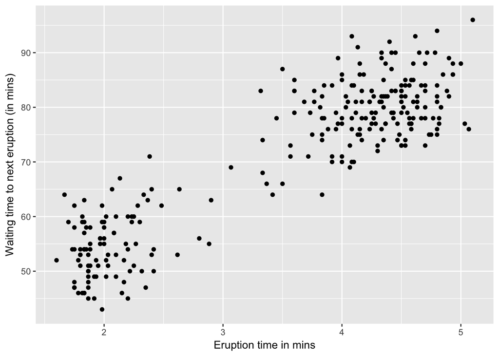

```r
#Do the analysis you need to do and create any relevant figures.

# Visualize relationship

ggplot(data = faithful, mapping = aes(x = eruptions, y = waiting)) +
        geom_point() +
        labs(x = "Eruption time in mins", y = "Waiting time to next eruption (in mins)")
```

```r
# Strength of correlation
cor(faithful$eruptions, faithful$waiting)
```

```
## [1] 0.9008112
```

Predict the waiting time to the next eruption if the last eruption was 4.2 minutes long and was 5 minutes ago:

```r
# Predict
# Use Linear Regression
fit <- lm(waiting~eruptions, data = faithful)

summary(fit)
```

```
##
## Call:
## lm(formula = waiting ~ eruptions, data = faithful)
##
## Residuals:
##      Min       1Q   Median       3Q      Max
## -12.0796  -4.4831   0.2122   3.9246  15.9719
##
## Coefficients:
##             Estimate Std. Error t value Pr(>|t|)
## (Intercept)  33.4744     1.1549   28.98   <2e-16 ***
## eruptions    10.7296     0.3148   34.09   <2e-16 ***
## ---
## Signif. codes:  0 '***' 0.001 '**' 0.01 '*' 0.05 '.' 0.1 ' ' 1
##
## Residual standard error: 5.914 on 270 degrees of freedom
## Multiple R-squared:  0.8115, Adjusted R-squared:  0.8108
## F-statistic:  1162 on 1 and 270 DF,  p-value: < 2.2e-16
```

```r
# y = mx + c
# dependent_variable =  slope*independent_variable + y-intercept
# here:

#predicted_waiting_time <- 10.7296*eruption_time + 33.4744

# 78.54 minutes is the waiting time to the next eruption if the last eruption was 4.2 minutes long.
```

Conclusion:

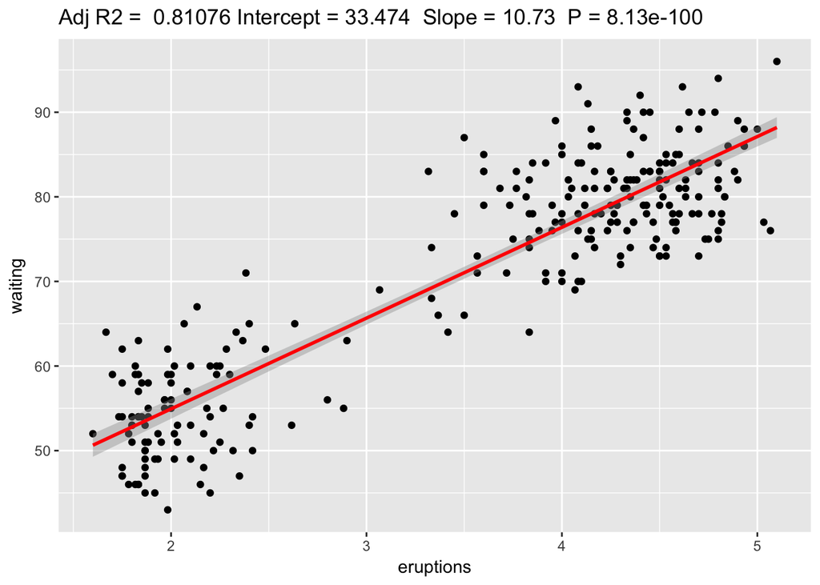

```r
# Visualization of linear regression predictions/conclusions

ggplot(fit$model, aes_string(x = names(fit$model)[2], y = names(fit$model)[1])) + geom_point() +
stat_smooth(method = "lm", col = "red") +
labs(title = paste("Adj R2 = ",signif(summary(fit)$adj.r.squared, 5),
"Intercept =",signif(fit$coef[[1]],5 ),
" Slope =",signif(fit$coef[[2]], 5),
" P =",signif(summary(fit)$coef[2,4], 5)))
```

# Exercise 4

How strongly are the ratings from the site Rotton Tomatoes correlated with user scores for films? To answer this question, we will use the dataset `fandango` which is in the package `fivethirtyeight`. The Rotton Tomatoes score for the film is in variable `rottentomatoes` and the user score for the film is `rottentomatoes_user`. Create a linear model for the user rating as a function of the Rotton Tomatoes rating. If a movie gets a score of 73 from Rotten Tomatoes, what score would you expect a user to give the movie?

```r
#Load any required packages
library(fivethirtyeight)

# View
head(fandango)
```

```
## # A tibble: 6 × 23
##                      film  year rottentomatoes rottentomatoes_user
##                     <chr> <dbl>          <int>               <int>
## 1 Avengers: Age of Ultron  2015             74                  86
## 2              Cinderella  2015             85                  80
## 3                 Ant-Man  2015             80                  90
## 4         Do You Believe?  2015             18                  84
## 5  Hot Tub Time Machine 2  2015             14                  28
## 6       The Water Diviner  2015             63                  62
## # ... with 19 more variables: metacritic <int>, metacritic_user <dbl>,
## #   imdb <dbl>, fandango_stars <dbl>, fandango_ratingvalue <dbl>,
## #   rt_norm <dbl>, rt_user_norm <dbl>, metacritic_norm <dbl>,
## #   metacritic_user_nom <dbl>, imdb_norm <dbl>, rt_norm_round <dbl>,
## #   rt_user_norm_round <dbl>, metacritic_norm_round <dbl>,
## #   metacritic_user_norm_round <dbl>, imdb_norm_round <dbl>,
## #   metacritic_user_vote_count <int>, imdb_user_vote_count <int>,
## #   fandango_votes <int>, fandango_difference <dbl>
```

```r
?fandango
```

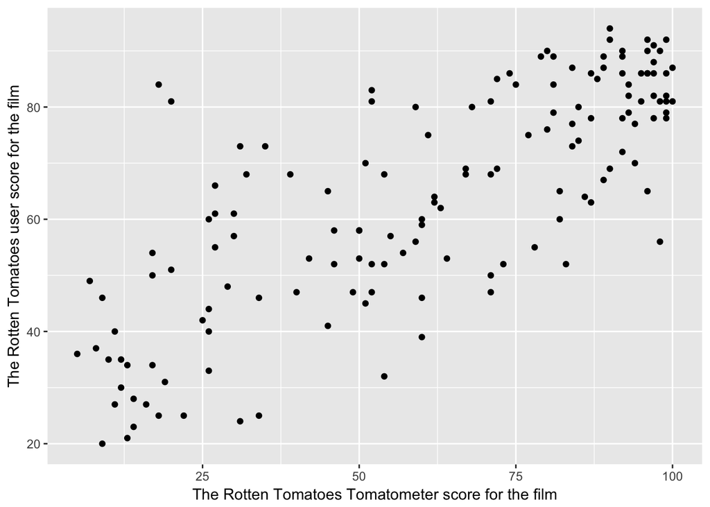

```r
# Create helpful figures and run the appropriate analysis.

# Visualisation

ggplot(data = fandango, mapping = aes(x = rottentomatoes, y = rottentomatoes_user)) +
        geom_point() +
        labs(x = "The Rotten Tomatoes Tomatometer score for the film", y = "The Rotten Tomatoes user score for the film")
```

```r
# Strength of correlation

cor(fandango$rottentomatoes, fandango$rottentomatoes_user)
```

```
## [1] 0.7814396
```

```r
# Prediction using simple linear regression model

fit2 <- lm(rottentomatoes_user~rottentomatoes, data = fandango)

# summary of the prediction model
summary(fit2)
```

```
##
## Call:
## lm(formula = rottentomatoes_user ~ rottentomatoes, data = fandango)
##
## Residuals:
##     Min      1Q  Median      3Q     Max
## -28.324  -7.995  -0.532   8.820  42.348
##
## Coefficients:
##                Estimate Std. Error t value Pr(>|t|)
## (Intercept)    32.31553    2.34251   13.79   <2e-16 ***
## rottentomatoes  0.51868    0.03451   15.03   <2e-16 ***
## ---
## Signif. codes:  0 '***' 0.001 '**' 0.01 '*' 0.05 '.' 0.1 ' ' 1
##
## Residual standard error: 12.54 on 144 degrees of freedom
## Multiple R-squared:  0.6106, Adjusted R-squared:  0.6079
## F-statistic: 225.8 on 1 and 144 DF,  p-value: < 2.2e-16
```

If a movie gets a score of 73 from Rotten Tomatoes, what score would you expect a user to give the movie?

```r
# y = c + mx
# dependent_variable = y_intercept + slope*independent_variable

rottentomatoes_score <- 73

expected_user_score <- 32.31553 + 0.51868 * rottentomatoes_score

# If a movie gets a score of 73 from Rotten Tomatoes, we would expect a user to give 70.17917 score to that particular movie
```

[figure not shown]

```r
# Visualization of linear regression predictions/conclusions

ggplot(fit2$model, aes_string(x = names(fit2$model)[2], y = names(fit2$model)[1])) + geom_point() +
stat_smooth(method = "lm", col = "red") +
labs(title = paste("Adj R2 = ",signif(summary(fit)$adj.r.squared, 5),
"Intercept =",signif(fit2$coef[[1]],5 ),
" Slope =",signif(fit2$coef[[2]], 5),
" P =",signif(summary(fit2)$coef[2,4], 5)))
```